# Statistics: The science of Decisions

## Performing statistical tests on data obtained from performing a Stroop test

## Introduction

In a Stroop task, participants are presented with a list of words, with each word displayed in a color of ink. The participant’s task is to say out loud the color of the ink in which the word is printed. The task has two conditions: a congruent words condition, and an incongruent words condition. In the congruent words condition, the words being displayed are color words whose names match the colors in which they are printed. In the incongruent words condition, the words displayed are color words whose names do not match the colors in which they are printed. In each case, we measure the time it takes to name the ink colors in equally-sized lists. Each participant will go through and record a time from each condition.

### Q1. What is our independent variable? What is our dependent variable?

The independent variable is match between the color and the displayed word.

The dependent variable is the time taken to name the ink colors.

### Q2. What is an appropriate set of hypotheses for this task? What kind of statistical test do you expect to perform? Justify your choices.

**2a. Null hypothesis** : The population mean does not change even after the making the words incongruent.

**Alternate hypothesis** : The mean for the time taken to name the incongruent words is not equal to the mean for the time taken to name the congruent words.

**Mathematical Representation:**

H<sub>0</sub>: μ<sub>c</sub> - μ<sub>i</sub> = 0

H<sub>A</sub>: μ<sub>c</sub> - μ<sub>i</sub> ≠ 0

**2b.** A two tailed T-test can be performed. This is because, we assume the distributions are normal, the two samples are dependent and the sample size is very less.

### Q3. Report some descriptive statistics regarding this dataset. Include at least one measure of central tendency and at least one measure of variability.

[output not shown]

### 4. Provide one or two visualizations that show the distribution of the sample data. Write one or two sentences noting what you observe about the plot or plots.

```python
import matplotlib.pyplot as plt
%matplotlib inline
```

```python
def plot_the_values(filename):
    """
    This function plots the distribution
    of the sampled data.

    """
    with open(filename, 'r') as f_in:
        reader = csv.DictReader(f_in)
        data_cong = []
        data_incong = []
        for row in reader:
            data_cong.append(float(row['Congruent']))
            data_incong.append(float(row['Incongruent']))
    plt.hist( data_cong, range=(0,40) )
    plt.title('Distribution of times in congruency condition')
    plt.xlabel('Time')
    plt.show()


    plt.hist( data_incong, range=(0,40))
    plt.title('Distribution of times in incongruency condition')
    plt.xlabel('Time')
    plt.show()
```

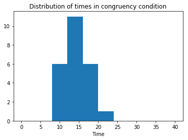

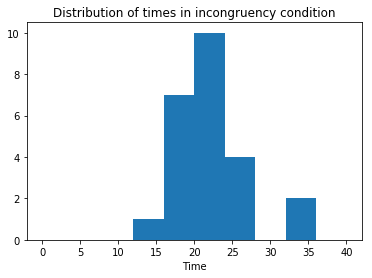

```python
plot_the_values('stroopdata.csv')
```

This clearly shows the difference in recognition times between congruency and incongruency conditions.

Evidently there are outliers, but the histogram confirms that the recognition time significantly varies in incongruency condition from that in the congruency condition.

### 5. Now, perform the statistical test and report your results. What is your confidence level and your critical statistic value? Do you reject the null hypothesis or fail to reject it? Come to a conclusion in terms of the experiment task. Did the results match up with your expectations?

degrees of freedom=23

t-critical=2.069

Therefore, the CI will be: -10.018 to -5.91

SEM=0.992

t=-8.022

p is less than 0.0001

Thus, the difference is extremely statistically significant.

Thus, there is stroop effect in recognizing the words.

### 6. Optional: What do you think is responsible for the effects observed? Can you think of an alternative or similar task that would result in a similar effect? Some research about the problem will be helpful for thinking about these two questions!

I think that the effect is caused due to misconception of the words as they are different from the color they are colored with.

Emotional stroop test would also result similar effects